# I) Dataset

Data set can be found:

- https://archive.ics.uci.edu/ml/datasets/Diabetes+130-US+hospitals+for+years+1999-2008

## 1) General context : problematic and target of the project

Our dataset is focusing on statistics concerning diabetics in the US from 1999 to 2008. The patients affected by diabetes are treated by some hospitals. In order to treat them in an efficient way, the hospitals try to make hypothesis on the readmission of the patients according to some features such as the health background of each patient.

Indeed, the hospitals settle the readmissions of the patients in 3 ways:

- Those that have been readmitted in less than 30 days
- Those that have been readmitted in more than 30 days
- Those that have not been readmitted at all

The purpose of this project is to bring an efficient model of prediction that could separate the patient into 3 groups as mentionned (< 30 days, > 30 days and no readmission).

This is a 3-class classification problem. Moreover, we have a dataset that could train our model. Therefore, it is a supervised model that could be trained.

## 2) Introduction to the dataset

### Importation of libraries

We need the following packages in order to import the dataset, work on it and show some plots if required.

```python
import pandas as pd
import numpy as np
```

### Importation of the dataset

```python
df = pd.read_csv("diabetic_dat.csv")
df
```

|  | encounter_id | patient_nbr | race | gender | age | weight | admission_type_id | discharge_disposition_id | admission_source_id | time_in_hospital | ... | citoglipton | insulin | glyburide-metformin | glipizide-metformin | glimepiride-pioglitazone | metformin-rosiglitazone | metformin-pioglitazone | change | diabetesMed | readmitted |
| --- | --- | --- | --- | --- | --- | --- | --- | --- | --- | --- | --- | --- | --- | --- | --- | --- | --- | --- | --- | --- | --- |
| 0 | 2278392 | 8222157 | Caucasian | Female | [0-10) | ? | 6 | 25 | 1 | 1 | ... | No | No | No | No | No | No | No | No | No | NO |
| 1 | 149190 | 55629189 | Caucasian | Female | [10-20) | ? | 1 | 1 | 7 | 3 | ... | No | Up | No | No | No | No | No | Ch | Yes | >30 |
| 2 | 64410 | 86047875 | AfricanAmerican | Female | [20-30) | ? | 1 | 1 | 7 | 2 | ... | No | No | No | No | No | No | No | No | Yes | NO |
| 3 | 500364 | 82442376 | Caucasian | Male | [30-40) | ? | 1 | 1 | 7 | 2 | ... | No | Up | No | No | No | No | No | Ch | Yes | NO |
| 4 | 16680 | 42519267 | Caucasian | Male | [40-50) | ? | 1 | 1 | 7 | 1 | ... | No | Steady | No | No | No | No | No | Ch | Yes | NO |
| ... | ... | ... | ... | ... | ... | ... | ... | ... | ... | ... | ... | ... | ... | ... | ... | ... | ... | ... | ... | ... | ... |
| 101761 | 443847548 | 100162476 | AfricanAmerican | Male | [70-80) | ? | 1 | 3 | 7 | 3 | ... | No | Down | No | No | No | No | No | Ch | Yes | >30 |
| 101762 | 443847782 | 74694222 | AfricanAmerican | Female | [80-90) | ? | 1 | 4 | 5 | 5 | ... | No | Steady | No | No | No | No | No | No | Yes | NO |
| 101763 | 443854148 | 41088789 | Caucasian | Male | [70-80) | ? | 1 | 1 | 7 | 1 | ... | No | Down | No | No | No | No | No | Ch | Yes | NO |
| 101764 | 443857166 | 31693671 | Caucasian | Female | [80-90) | ? | 2 | 3 | 7 | 10 | ... | No | Up | No | No | No | No | No | Ch | Yes | NO |
| 101765 | 443867222 | 175429310 | Caucasian | Male | [70-80) | ? | 1 | 1 | 7 | 6 | ... | No | No | No | No | No | No | No | No | No | NO |

101766 rows × 50 columns

We have a dataset of 101766 registred diabetics according 50 features.

### Description of the dataset

```python
df.head()
```

|  | encounter_id | patient_nbr | race | gender | age | weight | admission_type_id | discharge_disposition_id | admission_source_id | time_in_hospital | ... | citoglipton | insulin | glyburide-metformin | glipizide-metformin | glimepiride-pioglitazone | metformin-rosiglitazone | metformin-pioglitazone | change | diabetesMed | readmitted |
| --- | --- | --- | --- | --- | --- | --- | --- | --- | --- | --- | --- | --- | --- | --- | --- | --- | --- | --- | --- | --- | --- |
| 0 | 2278392 | 8222157 | Caucasian | Female | [0-10) | ? | 6 | 25 | 1 | 1 | ... | No | No | No | No | No | No | No | No | No | NO |
| 1 | 149190 | 55629189 | Caucasian | Female | [10-20) | ? | 1 | 1 | 7 | 3 | ... | No | Up | No | No | No | No | No | Ch | Yes | >30 |
| 2 | 64410 | 86047875 | AfricanAmerican | Female | [20-30) | ? | 1 | 1 | 7 | 2 | ... | No | No | No | No | No | No | No | No | Yes | NO |
| 3 | 500364 | 82442376 | Caucasian | Male | [30-40) | ? | 1 | 1 | 7 | 2 | ... | No | Up | No | No | No | No | No | Ch | Yes | NO |
| 4 | 16680 | 42519267 | Caucasian | Male | [40-50) | ? | 1 | 1 | 7 | 1 | ... | No | Steady | No | No | No | No | No | Ch | Yes | NO |

5 rows × 50 columns

```python
df.info()
```

```
<class 'pandas.core.frame.DataFrame'>
RangeIndex: 101766 entries, 0 to 101765
Data columns (total 50 columns):
 #   Column                    Non-Null Count   Dtype
---  ------                    --------------   -----
 0   encounter_id              101766 non-null  int64
 1   patient_nbr               101766 non-null  int64
 2   race                      101766 non-null  object
 3   gender                    101766 non-null  object
 4   age                       101766 non-null  object
 5   weight                    101766 non-null  object
 6   admission_type_id         101766 non-null  int64
 7   discharge_disposition_id  101766 non-null  int64
 8   admission_source_id       101766 non-null  int64
 9   time_in_hospital          101766 non-null  int64
```

[output cut: 42 more lines]

By checking the info, we can conclude few things:

- The **readmitted** column is the column will be using to know the classification (this is the target).
- The type of our features are integer or object (string).

### Names of features

```python
print(list(df))
```

```
['encounter_id', 'patient_nbr', 'race', 'gender', 'age', 'weight', 'admission_type_id', 'discharge_disposition_id', 'admission_source_id', 'time_in_hospital', 'payer_code', 'medical_specialty', 'num_lab_procedures', 'num_procedures', 'num_medications', 'number_outpatient', 'number_emergency', 'numbe…
```

From now, we have an idea of the dataset. The issues that we have to face with could be:

- The **lake of data** ("?" and "Nan" for example)
- **heterogeneous data** (integers and strings in the same column)
- **imprecise data** (the age registred by intervals)

That is why it could be better to **clean** and **analyze** the dataset in order the exploit it in the most efficient way.

## 3) Data Cleaning

### Duplicates

First, we have noticed duplicated data. We could remove it.

We will use **patient_nbr** as a reference since it has a unique numbers.

```python
df['patient_nbr'].value_counts()
```

```
88785891    40
43140906    28
88227540    23
1660293     23
23199021    23
            ..
66733983     1
20299680     1
112545       1
55422882     1
35488413     1
Name: patient_nbr, Length: 71518, dtype: int64
```

Out of **101,766** we find that only **71518** are unique.  
Let's try to keep the unique records.

```python
df = df.drop_duplicates(subset=['patient_nbr'])
df
```

|  | encounter_id | patient_nbr | race | gender | age | weight | admission_type_id | discharge_disposition_id | admission_source_id | time_in_hospital | ... | citoglipton | insulin | glyburide-metformin | glipizide-metformin | glimepiride-pioglitazone | metformin-rosiglitazone | metformin-pioglitazone | change | diabetesMed | readmitted |
| --- | --- | --- | --- | --- | --- | --- | --- | --- | --- | --- | --- | --- | --- | --- | --- | --- | --- | --- | --- | --- | --- |
| 0 | 2278392 | 8222157 | Caucasian | Female | [0-10) | ? | 6 | 25 | 1 | 1 | ... | No | No | No | No | No | No | No | No | No | NO |
| 1 | 149190 | 55629189 | Caucasian | Female | [10-20) | ? | 1 | 1 | 7 | 3 | ... | No | Up | No | No | No | No | No | Ch | Yes | >30 |
| 2 | 64410 | 86047875 | AfricanAmerican | Female | [20-30) | ? | 1 | 1 | 7 | 2 | ... | No | No | No | No | No | No | No | No | Yes | NO |
| 3 | 500364 | 82442376 | Caucasian | Male | [30-40) | ? | 1 | 1 | 7 | 2 | ... | No | Up | No | No | No | No | No | Ch | Yes | NO |
| 4 | 16680 | 42519267 | Caucasian | Male | [40-50) | ? | 1 | 1 | 7 | 1 | ... | No | Steady | No | No | No | No | No | Ch | Yes | NO |
| ... | ... | ... | ... | ... | ... | ... | ... | ... | ... | ... | ... | ... | ... | ... | ... | ... | ... | ... | ... | ... | ... |
| 101754 | 443842016 | 183087545 | Caucasian | Female | [70-80) | ? | 1 | 1 | 7 | 9 | ... | No | Steady | No | No | No | No | No | Ch | Yes | >30 |
| 101755 | 443842022 | 188574944 | Other | Female | [40-50) | ? | 1 | 1 | 7 | 14 | ... | No | Up | No | No | No | No | No | Ch | Yes | >30 |
| 101756 | 443842070 | 140199494 | Other | Female | [60-70) | ? | 1 | 1 | 7 | 2 | ... | No | Steady | No | No | No | No | No | No | Yes | >30 |
| 101758 | 443842340 | 120975314 | Caucasian | Female | [80-90) | ? | 1 | 1 | 7 | 5 | ... | No | Up | No | No | No | No | No | Ch | Yes | NO |
| 101765 | 443867222 | 175429310 | Caucasian | Male | [70-80) | ? | 1 | 1 | 7 | 6 | ... | No | No | No | No | No | No | No | No | No | NO |

71518 rows × 50 columns

### Useless features

Let's run some tests on our different features and see if some columns can be removed.

Weight

```python
numberPresentRows =  df.loc[(df['weight'] != '?'),'weight']
numberMissingRows = len(df.index)
print(len(numberPresentRows))
```

```
2853
```

Only 2853 rows have no missing weight.

```python
numberPresentRows =  df.loc[(df['weight'] != '?')].weight.count()
numberMissingRows = len(df.index)
print("percentage of missing rows of {} {} %".format("weight",100-((numberPresentRows/numberMissingRows)*100)//1))
```

```
percentage of missing rows of weight 97.0 %
```

We can conclude that the **weight** feature is almost negligible because of its amount of missing data representing 97% of the dataset.

Drugs

```python
drugslist = ['metformin', 'repaglinide', 'nateglinide', 'chlorpropamide', 'glimepiride', 'acetohexamide', 'glipizide', 'glyburide', 'tolbutamide', 'pioglitazone', 'rosiglitazone', 'acarbose', 'miglitol', 'troglitazone', 'tolazamide', 'examide', 'citoglipton', 'insulin', 'glyburide-metformin', 'glipizide-metformin', 'glimepiride-pioglitazone', 'metformin-rosiglitazone', 'metformin-pioglitazone']
for i in range(len(drugslist)):
    numberPresentRows =  len(df.loc[(df[drugslist[i]] != 'No'),drugslist[i]])
    numberMissingRows = len(df.index)
    print( "percentage of patients not using the drug of {} {} %".format(drugslist[i],100-((numberPresentRows/numberMissingRows)*100)//1))
```

```
percentage of patients not using the drug of metformin 80.0 %
percentage of patients not using the drug of repaglinide 99.0 %
percentage of patients not using the drug of nateglinide 100.0 %
percentage of patients not using the drug of chlorpropamide 100.0 %
percentage of patients not using the drug of glimepiride 95.0 %
percentage of patients not using the drug of acetohexamide 100.0 %
percentage of patients not using the drug of glipizide 88.0 %
percentage of patients not using the drug of glyburide 90.0 %
percentage of patients not using the drug of tolbutamide 100.0 %
percentage of patients not using the drug of pioglitazone 93.0 %
percentage of patients not using the drug of rosiglitazone 94.0 %
percentage of patients not using the drug of acarbose 100.0 %
percentage of patients not using the drug of miglitol 100.0 %
percentage of patients not using the drug of troglitazone 100.0 %
percentage of patients not using the drug of tolazamide 100.0 %
percentage of patients not using the drug of examide 100.0 %
percentage of patients not using the drug of citoglipton 100.0 %
percentage of patients not using the drug of insulin 49.0 %
percentage of patients not using the drug of glyburide-metformin 100.0 %
percentage of patients not using the drug of glipizide-metformin 100.0 %
percentage of patients not using the drug of glimepiride-pioglitazone 100.0 %
percentage of patients not using the drug of metformin-rosiglitazone 100.0 %
percentage of patients not using the drug of metformin-pioglitazone 100.0 %
```

We can see that a lot of the drugs are included in our dataset yet not really used by the patients  
meaning that it doesn't really affect the our target **readdmited** column.

We decide remove every drug that has less that < 5% impact.

We will also remove every column that doesn't affect our work directly such as:

- incounter_id
- patient_nbr
- payer_code

```python
columns_drop_list = ['encounter_id', 'patient_nbr', 'weight', 'payer_code','repaglinide', 'nateglinide', 'chlorpropamide','acetohexamide','tolbutamide', 'acarbose', 'miglitol', 'troglitazone', 'tolazamide', 'examide', 'citoglipton', 'glyburide-metformin', 'glipizide-metformin', 'glimepiride-pioglitazone', 'metformin-rosiglitazone', 'metformin-pioglitazone','medical_specialty']
df.drop(columns_drop_list,axis = 1, inplace=True)
```

```python
df.info()
```

```
<class 'pandas.core.frame.DataFrame'>
Int64Index: 71518 entries, 0 to 101765
Data columns (total 29 columns):
 #   Column                    Non-Null Count  Dtype
---  ------                    --------------  -----
 0   race                      71518 non-null  object
 1   gender                    71518 non-null  object
 2   age                       71518 non-null  object
 3   admission_type_id         71518 non-null  int64
 4   discharge_disposition_id  71518 non-null  int64
 5   admission_source_id       71518 non-null  int64
 6   time_in_hospital          71518 non-null  int64
 7   num_lab_procedures        71518 non-null  int64
 8   num_procedures            71518 non-null  int64
 9   num_medications           71518 non-null  int64
```

[output cut: 21 more lines]

### Mapping the dataset

In order to manipulate and work with our data more easily, we decided to **map** the data.

That is to say, we assign numeric values to all the data.

**Diag**

We replace "V" or "E" by "0".

```python
#start by setting all values containing E or V into 0 (as one category)
df.loc[df['diag_1'].str.contains('V',na=False,case=False), 'diag_1'] = 0
df.loc[df['diag_1'].str.contains('E',na=False,case=False), 'diag_1'] = 0
df.loc[df['diag_2'].str.contains('V',na=False,case=False), 'diag_2'] = 0
df.loc[df['diag_2'].str.contains('E',na=False,case=False), 'diag_2'] = 0
df.loc[df['diag_3'].str.contains('V',na=False,case=False), 'diag_3'] = 0
df.loc[df['diag_3'].str.contains('E',na=False,case=False), 'diag_3'] = 0
```

The missing data is replace by "-1".

```python
#setting all missing values into -1
df['diag_1'] = df['diag_1'].replace('?', -1)
df['diag_2'] = df['diag_2'].replace('?', -1)
df['diag_3'] = df['diag_3'].replace('?', -1)
```

Then , we assign a unique value to intervals.

```python
#No all diag values can be converted into numeric values
df['diag_1'] = df['diag_1'].astype(float)
df['diag_2'] = df['diag_2'].astype(float)
df['diag_3'] = df['diag_3'].astype(float)

df['diag_1'].loc[(df['diag_1']>=1) & (df['diag_1']< 140)] = 1
df['diag_1'].loc[(df['diag_1']>=140) & (df['diag_1']< 240)] = 2
df['diag_1'].loc[(df['diag_1']>=240) & (df['diag_1']< 280)] = 3
df['diag_1'].loc[(df['diag_1']>=280) & (df['diag_1']< 290)] = 4
df['diag_1'].loc[(df['diag_1']>=290) & (df['diag_1']< 320)] = 5
df['diag_1'].loc[(df['diag_1']>=320) & (df['diag_1']< 390)] = 6
df['diag_1'].loc[(df['diag_1']>=390) & (df['diag_1']< 460)] = 7
df['diag_1'].loc[(df['diag_1']>=460) & (df['diag_1']< 520)] = 8
df['diag_1'].loc[(df['diag_1']>=520) & (df['diag_1']< 580)] = 9
df['diag_1'].loc[(df['diag_1']>=580) & (df['diag_1']< 630)] = 10
df['diag_1'].loc[(df['diag_1']>=630) & (df['diag_1']< 680)] = 11
df['diag_1'].loc[(df['diag_1']>=680) & (df['diag_1']< 710)] = 12
df['diag_1'].loc[(df['diag_1']>=710) & (df['diag_1']< 740)] = 13
df['diag_1'].loc[(df['diag_1']>=740) & (df['diag_1']< 760)] = 14
df['diag_1'].loc[(df['diag_1']>=760) & (df['diag_1']< 780)] = 15
df['diag_1'].loc[(df['diag_1']>=780) & (df['diag_1']< 800)] = 16
df['diag_1'].loc[(df['diag_1']>=800) & (df['diag_1']< 1000)] = 17
df['diag_1'].loc[(df['diag_1']==-1)] = 0

df['diag_2'].loc[(df['diag_2']>=1) & (df['diag_2']< 140)] = 1
df['diag_2'].loc[(df['diag_2']>=140) & (df['diag_2']< 240)] = 2
df['diag_2'].loc[(df['diag_2']>=240) & (df['diag_2']< 280)] = 3
df['diag_2'].loc[(df['diag_2']>=280) & (df['diag_2']< 290)] = 4
df['diag_2'].loc[(df['diag_2']>=290) & (df['diag_2']< 320)] = 5
df['diag_2'].loc[(df['diag_2']>=320) & (df['diag_2']< 390)] = 6
df['diag_2'].loc[(df['diag_2']>=390) & (df['diag_2']< 460)] = 7
df['diag_2'].loc[(df['diag_2']>=460) & (df['diag_2']< 520)] = 8
df['diag_2'].loc[(df['diag_2']>=520) & (df['diag_2']< 580)] = 9
df['diag_2'].loc[(df['diag_2']>=580) & (df['diag_2']< 630)] = 10
df['diag_2'].loc[(df['diag_2']>=630) & (df['diag_2']< 680)] = 11
df['diag_2'].loc[(df['diag_2']>=680) & (df['diag_2']< 710)] = 12
df['diag_2'].loc[(df['diag_2']>=710) & (df['diag_2']< 740)] = 13
df['diag_2'].loc[(df['diag_2']>=740) & (df['diag_2']< 760)] = 14
df['diag_2'].loc[(df['diag_2']>=760) & (df['diag_2']< 780)] = 15
df['diag_2'].loc[(df['diag_2']>=780) & (df['diag_2']< 800)] = 16
df['diag_2'].loc[(df['diag_2']>=800) & (df['diag_2']< 1000)] = 17
df['diag_2'].loc[(df['diag_2']==-1)] = 0

df['diag_3'].loc[(df['diag_3']>=1) & (df['diag_3']< 140)] = 1
df['diag_3'].loc[(df['diag_3']>=140) & (df['diag_3']< 240)] = 2
df['diag_3'].loc[(df['diag_3']>=240) & (df['diag_3']< 280)] = 3
df['diag_3'].loc[(df['diag_3']>=280) & (df['diag_3']< 290)] = 4
df['diag_3'].loc[(df['diag_3']>=290) & (df['diag_3']< 320)] = 5
df['diag_3'].loc[(df['diag_3']>=320) & (df['diag_3']< 390)] = 6
df['diag_3'].loc[(df['diag_3']>=390) & (df['diag_3']< 460)] = 7
df['diag_3'].loc[(df['diag_3']>=460) & (df['diag_3']< 520)] = 8
df['diag_3'].loc[(df['diag_3']>=520) & (df['diag_3']< 580)] = 9
df['diag_3'].loc[(df['diag_3']>=580) & (df['diag_3']< 630)] = 10
df['diag_3'].loc[(df['diag_3']>=630) & (df['diag_3']< 680)] = 11
df['diag_3'].loc[(df['diag_3']>=680) & (df['diag_3']< 710)] = 12
df['diag_3'].loc[(df['diag_3']>=710) & (df['diag_3']< 740)] = 13
df['diag_3'].loc[(df['diag_3']>=740) & (df['diag_3']< 760)] = 14
df['diag_3'].loc[(df['diag_3']>=760) & (df['diag_3']< 780)] = 15
df['diag_3'].loc[(df['diag_3']>=780) & (df['diag_3']< 800)] = 16
df['diag_3'].loc[(df['diag_3']>=800) & (df['diag_3']< 1000)] = 17
df['diag_3'].loc[(df['diag_3']==-1)] = 0
```

[output not shown]

[output cut: 503 more lines]

[output not shown]

```python
df[['diag_1','diag_2','diag_3']]
```

|  | diag_1 | diag_2 | diag_3 |
| --- | --- | --- | --- |
| 0 | 3.0 | 0.0 | 0.0 |
| 1 | 3.0 | 3.0 | 3.0 |
| 2 | 11.0 | 3.0 | 0.0 |
| 3 | 1.0 | 3.0 | 7.0 |
| 4 | 2.0 | 2.0 | 3.0 |
| ... | ... | ... | ... |
| 101754 | 9.0 | 9.0 | 3.0 |
| 101755 | 10.0 | 10.0 | 8.0 |
| 101756 | 17.0 | 10.0 | 7.0 |
| 101758 | 5.0 | 1.0 | 5.0 |
| 101765 | 9.0 | 9.0 | 16.0 |

71518 rows × 3 columns

We can see that our numerization works.

Let's do it with the other features that are non numerics values.

**Race**

We assign:

- "0" to "Caucasian"
- "1" to "AfricanAmerican"
- "2" to "Hispanic"
- "3" to "Asian"
- "4" to "Other"

```python
df.race.value_counts()
```

[output not shown]

```python
df['race'] = df['race'].replace('?','Other')
df.race.value_counts()
```

```
Caucasian          53491
AfricanAmerican    12887
Other               3126
Hispanic            1517
Asian                497
Name: race, dtype: int64
```

```python
df['race'] = df['race'].replace('Caucasian', 0)
df['race'] = df['race'].replace('AfricanAmerican', 1)
df['race'] = df['race'].replace('Hispanic', 2)
df['race'] = df['race'].replace('Asian', 3)
df['race'] = df['race'].replace('Other', 4)
df.race.value_counts()
```

```
0    53491
1    12887
4     3126
2     1517
3      497
Name: race, dtype: int64
```

**Gender**

We assign:

- "0" to "Female"
- "1" to "Male"

In order to simplify the work, we will consider "Unknown/Invalid" as "Female"

```python
df['gender'] = df['gender'].replace('Unknown/Invalid', 'Female')
df.gender.value_counts()
```

```
Female    38028
Male      33490
Name: gender, dtype: int64
```

```python
df['gender'] = df['gender'].replace('Male', 1)
df['gender'] = df['gender'].replace('Female', 0)
df.gender.value_counts()
```

```
0    38028
1    33490
Name: gender, dtype: int64
```

**Age**

The age is given by intervals.

So, we decided to take the average for each interval and to assign it.

```python
df.age.value_counts()
```

```
[70-80)     18210
[60-70)     15960
[50-60)     12466
[80-90)     11589
[40-50)      6878
[30-40)      2699
[90-100)     1900
[20-30)      1127
[10-20)       535
[0-10)        154
Name: age, dtype: int64
```

```python
#we will take the middle of every interval for example [0-10] -> 5
for i in range(0,10):
    df['age'] = df['age'].replace('['+str(10*i)+'-'+str(10*(i+1))+')', i*10+5)
df['age'].value_counts()
```

```
75    18210
65    15960
55    12466
85    11589
45     6878
35     2699
95     1900
25     1127
15      535
5       154
Name: age, dtype: int64
```

**Max_glu_serum**

We assign:

- "0" to "None"
- "1" to "Norm"
- "2" to ">200"
- "3" to ">300"

```python
df.max_glu_serum.value_counts()
```

```
None    68062
Norm     1731
>200      969
>300      756
Name: max_glu_serum, dtype: int64
```

```python
df['max_glu_serum']=df['max_glu_serum'].replace("None", 0)
df['max_glu_serum']=df['max_glu_serum'].replace("Norm", 1)
df['max_glu_serum']=df['max_glu_serum'].replace(">200", 2)
df['max_glu_serum']=df['max_glu_serum'].replace(">300", 3)
df.max_glu_serum.value_counts()
```

```
0    68062
1     1731
2      969
3      756
Name: max_glu_serum, dtype: int64
```

**A1Cresult**

We assign:

- "0" to "None"
- "1" to "Norm"
- "2" to ">7"
- "3" to ">8"

```python
df.A1Cresult.value_counts()
```

```
None    58532
>8       6304
Norm     3791
>7       2891
Name: A1Cresult, dtype: int64
```

```python
df['A1Cresult']=df['A1Cresult'].replace("None", 0)
df['A1Cresult']=df['A1Cresult'].replace("Norm", 1)
df['A1Cresult']=df['A1Cresult'].replace(">7", 2)
df['A1Cresult']=df['A1Cresult'].replace(">8", 3)
df.A1Cresult.value_counts()
```

```
0    58532
3     6304
1     3791
2     2891
Name: A1Cresult, dtype: int64
```

**Drugs**

We assign:

- "0" to "No"
- "1" to "Down"
- "2" to "Steady"
- "3" to "Up"

```python
df.insulin.value_counts()
```

```
No        34921
Steady    22129
Down       7505
Up         6963
Name: insulin, dtype: int64
```

```python
#we will work with the drugs that we decided to keep into our work
drug_list = ['metformin', 'glimepiride', 'glipizide', 'glyburide', 'pioglitazone', 'rosiglitazone', 'insulin']
for i in drug_list:
    df[i] = df[i].replace('No', 0)
    df[i] = df[i].replace('Steady', 2)
    df[i] = df[i].replace('Down', 1)
    df[i] = df[i].replace('Up', 3)
df.insulin.value_counts()
```

```
0    34921
2    22129
1     7505
3     6963
Name: insulin, dtype: int64
```

**Change**

We assign:

- "0" to "No"
- "1" to "Ch"

```python
df.change.value_counts()
```

```
No    39494
Ch    32024
Name: change, dtype: int64
```

```python
df['change']=df['change'].replace('No', 0)
df['change']=df['change'].replace('Ch', 1)
df.change.value_counts()
```

```
0    39494
1    32024
Name: change, dtype: int64
```

**DiabetesMed**

We assign:

- "0" to "No"
- "1" to "Yes"

```python
df.diabetesMed.value_counts()
```

```
Yes    54319
No     17199
Name: diabetesMed, dtype: int64
```

```python
df['diabetesMed']=df['diabetesMed'].replace('Yes', 1)
df['diabetesMed']=df['diabetesMed'].replace('No', 0)
df.diabetesMed.value_counts()
```

```
1    54319
0    17199
Name: diabetesMed, dtype: int64
```

**Readmitted**

We assign:

- "0" to "No"
- "1" to ">30"
- "2" to "<30"

```python
df.readmitted.value_counts()
```

```
NO     42985
>30    22240
<30     6293
Name: readmitted, dtype: int64
```

```python
df['readmitted']=df['readmitted'].replace('NO', 0)
df['readmitted']=df['readmitted'].replace('>30', 1)
df['readmitted']=df['readmitted'].replace('<30', 2)
df.readmitted.value_counts()
```

```
0    42985
1    22240
2     6293
Name: readmitted, dtype: int64
```

```python
df.info()
```

```
<class 'pandas.core.frame.DataFrame'>
Int64Index: 71518 entries, 0 to 101765
Data columns (total 29 columns):
 #   Column                    Non-Null Count  Dtype
---  ------                    --------------  -----
 0   race                      71518 non-null  int64
 1   gender                    71518 non-null  int64
 2   age                       71518 non-null  int64
 3   admission_type_id         71518 non-null  int64
 4   discharge_disposition_id  71518 non-null  int64
 5   admission_source_id       71518 non-null  int64
 6   time_in_hospital          71518 non-null  int64
 7   num_lab_procedures        71518 non-null  int64
 8   num_procedures            71518 non-null  int64
 9   num_medications           71518 non-null  int64
```

[output cut: 21 more lines]

The data is cleaned. From now, we could manipulate it easily and visualize it through **plots** in order to find out some important predictors to fit our models.

## 4) Viewing and analysis of the dataset

### Importation of librairies

```python
import seaborn as sns
import matplotlib.pyplot as plt
%matplotlib inline
plt.style.use('ggplot')
```

### Correlation

Let us see what are the correlation between them in order to pick up only the most valuable features to fit our models.

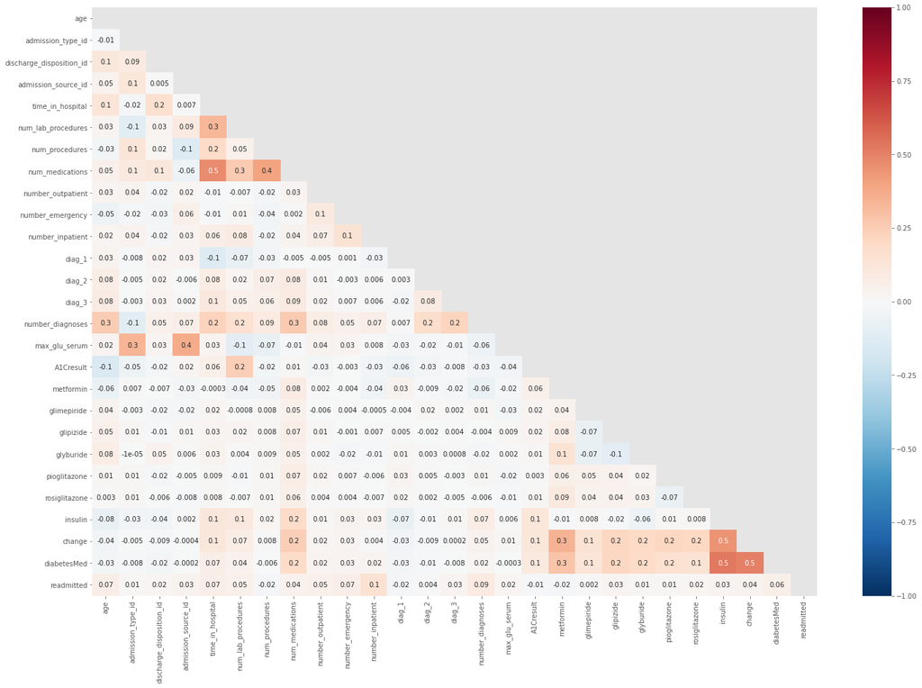

```python
matrix = np.triu(df.corr())
fig, ax = plt.subplots(figsize=(24,16))
sns.heatmap(df.corr(), annot=True, ax=ax, fmt='.1g', vmin=-1, vmax=1, center= 0, mask=matrix, cmap='RdBu_r')
plt.show()
```

According to our matrix correlation, we can see:

- **diabetesMed** is corrolated with **insulin** (0.5)
- **num_medications** is corrolated with **time_in_hospital**(0.5)

But we aim to find the most correlated features with our target, the **readmitted**.

We notice that our target has a low correlation with all the features (<0.1).

The most interesting ones are :

- **number_inpatient** (0.1)
- **number_diagnoses** (0.09)
- **number_emergency** (0.07)
- **age** (0.07)
- **diabetesMed** (0.06)

### Plots

We choose the **gender** and the **race** because they always could be interesting features to analyze.

Then, we will plot some interesting features that have the highest correlation with the target.

**Race**

[figure not shown]

```python
fig = plt.figure(figsize=(18, 6))
sns.countplot(data=df, x='race', hue='readmitted')
plt.show()
```

We can say that readmittion has simmilar distribution almost across different races.

**Gender**

[figure not shown]

```python
fig = plt.figure(figsize=(18, 6))
sns.countplot(data=df, x='gender', hue='readmitted')
plt.show()
```

We can see that there is slightly higher female patients. We know that this result is skewed by the **Unknown** patients considered as **Females**.

**Number_inpatient**

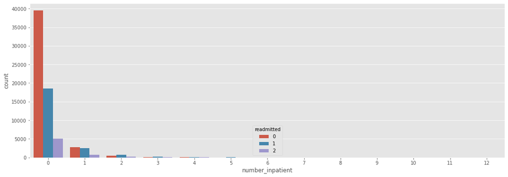

```python
fig = plt.figure(figsize=(18, 6))
sns.countplot(data=df, x='number_inpatient', hue='readmitted')
plt.show()
```

**Number_diagnoses**

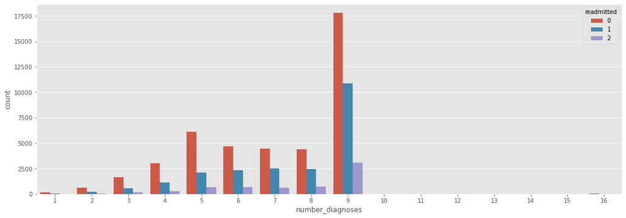

```python
fig = plt.figure(figsize=(18, 6))
sns.countplot(data=df, x='number_diagnoses', hue='readmitted')
plt.show()
```

This plot shows that the number of patients is higher for number of diagnoses 9 and very low for number 1. We can also say that the readmission increase with the number of diagnoses.

**Number_emergency**

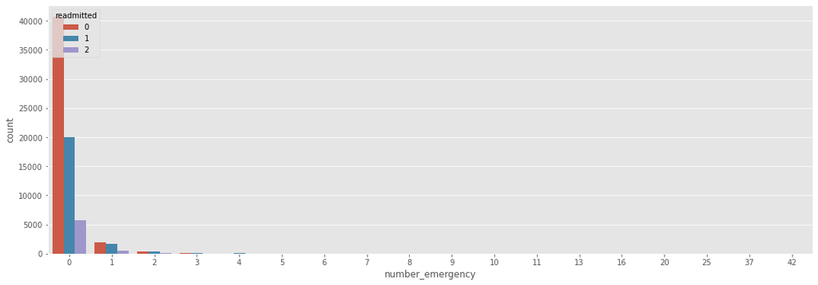

```python
fig = plt.figure(figsize=(18, 6))

sns.countplot(data=df, x='number_emergency', hue='readmitted')
plt.show()
```

The readmission is higher with a lower number of emergency.

**Age**

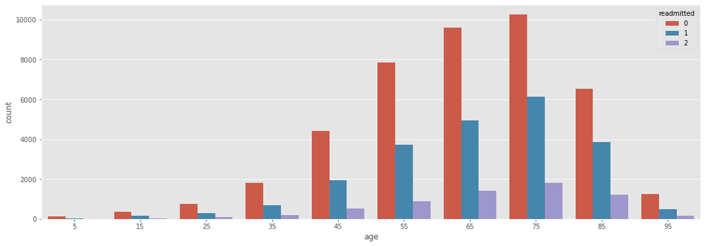

```python
fig = plt.figure(figsize=(18, 6))
sns.countplot(data=df, x='age', hue='readmitted')
plt.show()
```

we can see that there are few cases before the age of 40 and they peak around the age of 75.

**diabetesMed**

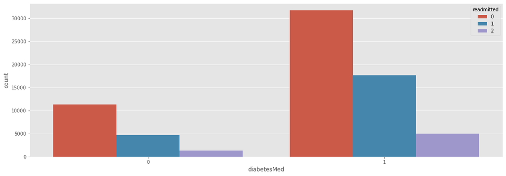

```python
fig = plt.figure(figsize=(18, 6))
sns.countplot(data=df, x='diabetesMed', hue='readmitted')
plt.show()
```

We can say that readmitted has the same distribution for the people with or without diabetes medication in terms of proportions between no readmission, < 30 days and > 30 days. But it is interesting to add that the patients that have medications are more concerned by readmission than the ones with no medications (3x more).

According to this, we have a clean dataset and a good analysis in order to apply some interesting models.

# II) Training a Machine Learning model

In order to predict the readmitted label, we have many choices.

The choice depends on:

- the lenght of the dataset (more or less than 100 000 rows)
- labelled or unlabelled dataset

We have a labelled dataset with less than 100 000 rows. So, the most adapted models are provided by:

- Naive Bayes
- SVM
- Random Forest
- Gradient Boosting

If we need speed, the most interesting model is **Naive Bayes**.

If we need accuracy, the most interesting is **Random Forest** and **Gradient Boosting**.

### Importation of librairies

From the librairy sklearn, we have an access to all the methods of model prediction previously introduced.

```python
from sklearn.model_selection import train_test_split
from sklearn.preprocessing import StandardScaler
from sklearn import metrics
from sklearn.model_selection import GridSearchCV
from sklearn.model_selection import RandomizedSearchCV
from sklearn.model_selection import cross_val_score
from sklearn.metrics import confusion_matrix
from sklearn.metrics import roc_curve, auc
from sklearn.metrics import classification_report
from sklearn.naive_bayes import GaussianNB
from sklearn.ensemble import RandomForestClassifier
from sklearn.ensemble import GradientBoostingClassifier
from sklearn.preprocessing import StandardScaler
```

```python
x = df[df.columns[0:df.shape[1]-1]]
y = df['readmitted']
print(y.value_counts())
```

```
0    42985
1    22240
2     6293
Name: readmitted, dtype: int64
```

### Data split

We split the data into 2 parts: a **training set** to fit our model and a **testing set** to evaluate its accuracy.

X represents the **predictors** and Y the **target**.

We decided to allocate **2/3** of the data to the training set and **1/3** to the testing set.

```python
x_train, x_test , y_train ,y_test = train_test_split(x,y,test_size=0.33)
print("X train: ",x_train.shape)
print("X test: ",x_test.shape)
print("Y train: ",y_train.shape)
print("Y test: ",y_test.shape)
```

```
X train:  (47917, 28)
X test:  (23601, 28)
Y train:  (47917,)
Y test:  (23601,)
```

### Data scaling

The scaling helps to have more homogeneous and calibrate numeric values.

```python
scaler = StandardScaler()
scaler.fit(x_train)

x_train = scaler.transform(x_train)
x_test = scaler.transform(x_test)

print(x_train)
print(x_test)
```

```
[[-0.45385712  1.0625802   1.20884907 ... -0.93452816 -0.90348008
  -1.78585591]
 [-0.45385712 -0.94110543  0.5838216  ... -0.93452816 -0.90348008
  -1.78585591]
 [ 3.84554913 -0.94110543 -0.04120587 ... -0.93452816 -0.90348008
   0.55995559]
 ...
 [-0.45385712  1.0625802   0.5838216  ...  1.81866603  1.10683127
   0.55995559]
 [-0.45385712  1.0625802   1.20884907 ...  0.90093463  1.10683127
   0.55995559]
 [-0.45385712 -0.94110543  0.5838216  ... -0.93452816 -0.90348008
   0.55995559]]
[[-0.45385712  1.0625802  -0.04120587 ...  0.90093463  1.10683127
   0.55995559]
 [-0.45385712  1.0625802  -1.91628828 ...  0.90093463  1.10683127
   0.55995559]
 [ 0.62099444  1.0625802   0.5838216  ... -0.93452816 -0.90348008
  -1.78585591]
 ...
 [-0.45385712 -0.94110543  1.20884907 ... -0.93452816 -0.90348008
  -1.78585591]
 [ 0.62099444 -0.94110543 -1.91628828 ...  0.90093463  1.10683127
   0.55995559]
 [-0.45385712  1.0625802  -0.66623334 ...  0.90093463 -0.90348008
   0.55995559]]
```

## 1) Differents models

Now we will start building our models and see which one is the best.

**Naive Bayes**

```python
naive_Bayes_model = GaussianNB()
naive_Bayes_model.fit(x_train,y_train)
naive_Bayes_model_pred = naive_Bayes_model.predict(x_test)
```

**Random Forest**

```python
random_forest_model = RandomForestClassifier()
random_forest_model.fit(x_train,y_train)
random_forest_model_pred = random_forest_model.predict(x_test)
```

**Gradient Boosting**

```python
gradient_boosting_model = GradientBoostingClassifier()
gradient_boosting_model.fit(x_train,y_train)
gradient_boosting_model_pred = gradient_boosting_model.predict(x_test)
```

Now that we built our models, we will see which model works best. Our purpose is to obtain the best **accuracy** possible.

```python
naive_Bayes_model_accuracy = naive_Bayes_model.score(x_test,y_test)
random_forest_model_accuracy = random_forest_model.score(x_test,y_test)
gradient_boosting_model_accuracy = gradient_boosting_model.score(x_test,y_test)

results = pd.DataFrame({
    'Model':['Naive Bayes','Random Forest','Gradient Boosting'],
    'Score':[naive_Bayes_model_accuracy,random_forest_model_accuracy,gradient_boosting_model_accuracy]
})

results_df = results.sort_values(by='Score',ascending=False)
results_df = results_df.set_index('Score')
results_df
```

| Score | Model |
| --- | --- |
| 0.613194 | Gradient Boosting |
| 0.605144 | Random Forest |
| 0.586373 | Naive Bayes |

## 2) Model improvement

To improve our models, we could split our testing set into 2 parts :

- **validation set**
- **testing set**

The validation test allow us to verify our model thanks to a score and a **confusion matrix**

```python
x_val_train, x_val_test, y_val_train, y_val_test = train_test_split(x_test, y_test, test_size=0.5, random_state=101)
```

```python
gradient_boosting_model_pred = gradient_boosting_model.predict(x_val_train)

print('\nGradient Boost initial Performance:')

print('F1 Score        : ', metrics.f1_score(y_val_train, gradient_boosting_model_pred,average='micro'))
print('Confusion Matrix:\n ', confusion_matrix(y_val_train, gradient_boosting_model_pred))
```

```
Gradient Boost initial Performance:
F1 Score        :  0.6120338983050847
Confusion Matrix:
  [[6652  371    4]
 [3182  560   15]
 [ 843  163   10]]
```

We can see that the score is about 60-62,5%

### Variables importance

Every feature doesn't have the same importance. That is why we can proceed to a **hyper parameter tuning** depending on the features with the best predictions.

```python
predictors = [x for
              x in df.columns[0:len(df.columns)-1]]
print(predictors)
```

```
['race', 'gender', 'age', 'admission_type_id', 'discharge_disposition_id', 'admission_source_id', 'time_in_hospital', 'num_lab_procedures', 'num_procedures', 'num_medications', 'number_outpatient', 'number_emergency', 'number_inpatient', 'diag_1', 'diag_2', 'diag_3', 'number_diagnoses', 'max_glu_ser…
```

This list of predictors is composed of the parameters that we have to tune according to their importance calculated below.

```
discharge_disposition_id    0.212364
number_inpatient            0.197544
number_diagnoses            0.084160
number_outpatient           0.053307
number_emergency            0.052759
age                         0.051986
admission_source_id         0.050013
num_medications             0.041165
diabetesMed                 0.036572
admission_type_id           0.036464
time_in_hospital            0.031541
num_lab_procedures          0.031397
diag_1                      0.027099
diag_2                      0.018712
race                        0.015107
num_procedures              0.013004
diag_3                      0.009769
A1Cresult                   0.009254
metformin                   0.008334
max_glu_serum               0.005404
insulin                     0.004674
glipizide                   0.003463
rosiglitazone               0.001485
glimepiride                 0.001343
pioglitazone                0.001059
glyburide                   0.001035
gender                      0.000824
change                      0.000162
dtype: float64
```

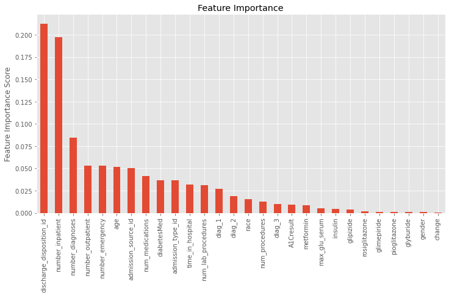

```python
feature_importance = pd.Series(gradient_boosting_model.feature_importances_,predictors).sort_values(ascending=False)
fig = plt.figure(figsize=(12,6))
print(feature_importance)
feature_importance.plot(kind = 'bar',title = 'Feature Importance')
plt.ylabel('Feature Importance Score')
```

We try the model with the most important features. We tried many combinations taking from 1 to 27 predictors.

```python
x_new = df[['discharge_disposition_id','number_inpatient','number_diagnoses','age','number_emergency','number_outpatient','num_medications','num_lab_procedures','admission_type_id','diabetesMed','diag_1','time_in_hospital']]
y_new = df['readmitted']
x_train_new, x_test_new , y_train_new ,y_test_new = train_test_split(x_new,y_new,test_size=0.33)

#print("X train: ",x_train_new.shape)
#print("X test: ",x_test_new.shape)
#print("Y train: ",y_train_new.shape)
#print("Y test: ",y_test_new.shape)

scaler = StandardScaler()
scaler.fit(x_train_new)
x_train_new = scaler.transform(x_train_new)
x_test_new = scaler.transform(x_test_new)
```

```python
naive_Bayes_model_new = GaussianNB()
naive_Bayes_model_new.fit(x_train_new,y_train_new)
naive_Bayes_model_pred_new = naive_Bayes_model_new.predict(x_test_new)

random_forest_model_new = RandomForestClassifier()
random_forest_model_new.fit(x_train_new,y_train_new)
random_forest_model_pred_new = random_forest_model_new.predict(x_test_new)

gradient_boosting_model_new = GradientBoostingClassifier()
gradient_boosting_model_new.fit(x_train_new,y_train_new)
gradient_boosting_model_pred_new = gradient_boosting_model_new.predict(x_test_new)
```

```python
naive_Bayes_model_accuracy_new = naive_Bayes_model_new.score(x_test_new,y_test_new)
random_forest_model_accuracy_new = random_forest_model_new.score(x_test_new,y_test_new)
gradient_boosting_model_accuracy_new = gradient_boosting_model_new.score(x_test_new,y_test_new)

results = pd.DataFrame({
    'Model':['Naive Bayes','Random Forest','Gradient Boosting'],
    'Score':[naive_Bayes_model_accuracy_new,random_forest_model_accuracy_new,gradient_boosting_model_accuracy_new]
})

results_df = results.sort_values(by='Score',ascending=False)
results_df = results_df.set_index('Score')
results_df
```

| Score | Model |
| --- | --- |
| 0.619296 | Gradient Boosting |
| 0.599975 | Naive Bayes |
| 0.596924 | Random Forest |

```python
x_val_train_new, x_val_test_new, y_val_train_new, y_val_test_new = train_test_split(x_test_new, y_test_new, test_size=0.5, random_state=101)

naive_Bayes_model_pred_new = naive_Bayes_model_new.predict(x_val_train_new)
random_forest_model_pred_new = random_forest_model_new.predict(x_val_train_new)
gradient_boosting_model_pred_new = gradient_boosting_model_new.predict(x_val_train_new)

print('\nPerformances:\n\n')
print('F1 Score Bayes       : ', metrics.f1_score(y_val_train_new, naive_Bayes_model_pred_new,average='micro'))
print('Confusion Matrix Bayes:\n ', confusion_matrix(y_val_train_new, naive_Bayes_model_pred_new))
print('\n')
print('F1 Score Random Forest       : ', metrics.f1_score(y_val_train_new, random_forest_model_pred_new,average='micro'))
print('Confusion Matrix Random Forest:\n ', confusion_matrix(y_val_train_new, random_forest_model_pred_new))
print('\n')
print('F1 Score Gradient       : ', metrics.f1_score(y_val_train_new, gradient_boosting_model_pred_new,average='micro'))
print('Confusion Matrix Gradient:\n ', confusion_matrix(y_val_train_new, gradient_boosting_model_pred_new))
```

```
Performances:


F1 Score Bayes       :  0.6027966101694915
Confusion Matrix Bayes:
  [[6424  564  130]
 [2867  602  151]
 [ 826  149   87]]


F1 Score Random Forest       :  0.6011016949152542
Confusion Matrix Random Forest:
  [[6105  967   46]
 [2608  978   34]
 [ 800  252   10]]


F1 Score Gradient       :  0.622457627118644
Confusion Matrix Gradient:
  [[6778  338    2]
 [3055  561    4]
 [ 901  155    6]]
```

We noticed some facts:

After many attempts, we managed to obtain an accuracy about 62.5%.

### Gradiant Boosting Model Tuning

We have to choose the best number of parameters in order to improve the learning rate. Thanks to this, the combination of the subsample models create a more powerful new model and we repeat this process.

Before that, we have to initialize the **boosting parameters**:

- **min_samples_split** : this should be a small proportion of our dataset (~1%)
- **min_samples_leaf** : this prevent from overfitting. This is based on testing and intuition.
- **max_depth** : this is based on the number of observation and predictors (5-8)
- **max_features** : usually start with square root
- **subsample** : usually 0.8
- **n_estimators** : this is the number of grid search to check the optimum number of trees. It tests out values from a range by a step that we choose.

Theses parameters are initialized. They after could be tuned in order to find the **optimum combination for the best accuracy score**.

```python
param_test = {'n_estimators':range(20,75,5)}
gsearch = GridSearchCV(estimator = GradientBoostingClassifier(learning_rate=0.1,
                                                               min_samples_split=350,
                                                               min_samples_leaf=50,
                                                               max_depth=8,
                                                               max_features='sqrt',
                                                               subsample=0.8,
                                                               random_state=101), param_grid = param_test, scoring='f1_micro',n_jobs=-1,cv=5)
gsearch.fit(x_train,y_train)
```

[output not shown]

```python
gsearch.best_params_, gsearch.best_score_
```

```
({'n_estimators': 70}, 0.6202599505384554)
```